# Lab 5

Eric Gleiter; Brandon Xicon

4/12/2020

*Note for readibilty all package/library checks and installlations are hidden on the html*

```r
#takes really long recommended just load this once
acc <- read.csv("https://raw.githubusercontent.com/xdaiISU/ds202materials/master/hwlabs/fars2017/accident.csv", stringsAsFactors = FALSE)
pers <- read.csv("https://raw.githubusercontent.com/xdaiISU/ds202materials/master/hwlabs/fars2017/person.csv", stringsAsFactors = FALSE)
```

**Part One:** **1) Are there some days of the week where more accidents happen than on others (use variable DAY_WEEK)?**

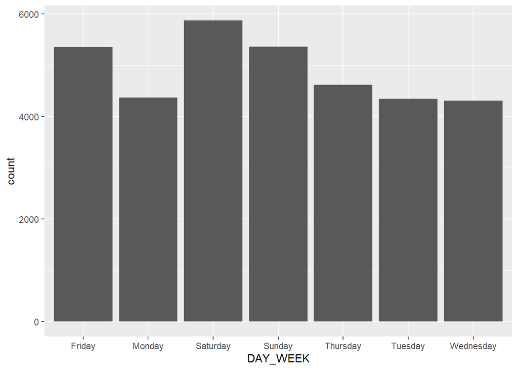

```r
ggplot(acc, aes(DAY_WEEK)) + geom_bar()
```

**2) What time of the day do accidents happen (use variable HOUR)?**

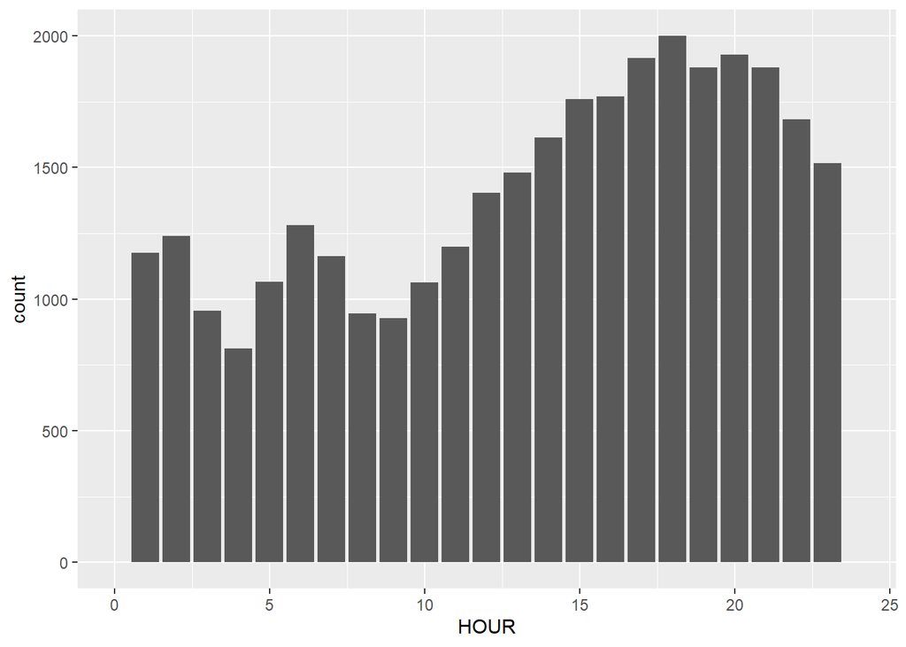

```r
ggplot(acc, aes(HOUR)) + geom_bar() + xlim(0,24)
```

Most accident occur later in the day with a peak around the 18 o’clock mark (6pm). Additionally there are approxamently 260 accidents with a time of 99:99. I took this to mean the time was unknown which is why the value is not a vailed time this accidents are not shown on the graph.

**3) What is the number of accidents with at least one drunk driver (use variable DRUNK_DR)?**

```r
acc %>%
  filter(DRUNK_DR != 0) %>%
  summarise(n = n()) %>%
  head()
```

```
##      n
## 1 8769
```

8769 accident invlolve a drunk driver.

**Part Two:** **4. In the person table, identify drivers (PER_TYP == 1, see FARS manual) and subset on them.**

```r
pers <- pers %>% filter(PER_TYP == 1)
```

5. Join accident and person table (work out which variable(s) to use)

```r
data<-full_join(acc,pers)
```

**6. Tally the number of accidents by day of the week (DAY_WEEK), hour of the day (HOUR) and gender (SEX). Visualize the results.**

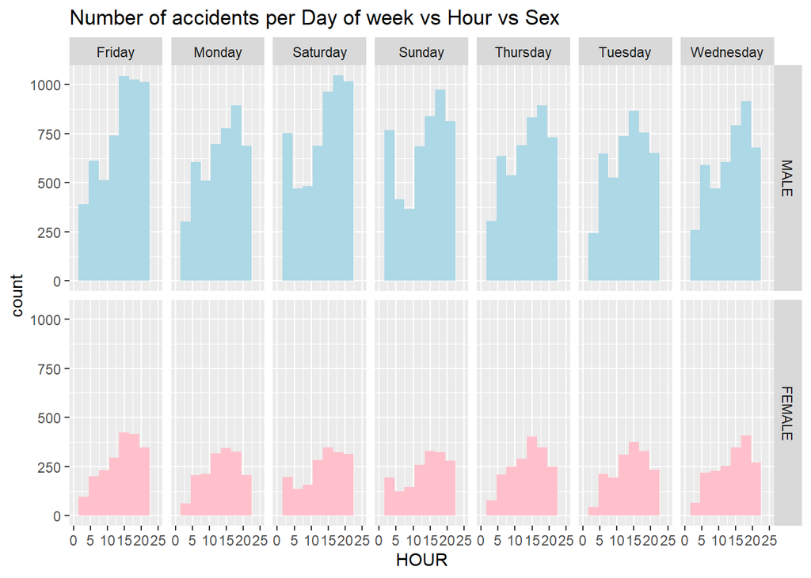

```r
data %>%
  mutate(SEX = factor(SEX, levels=c(1, 2), labels=c('MALE', 'FEMALE')))%>%
  filter(!is.na(SEX)) %>%
  ggplot(aes(x=HOUR,fill=SEX))+
    scale_fill_manual(values=c("Light Blue","Pink")) +
    geom_histogram(binwidth=3) +
    facet_grid(SEX~DAY_WEEK) +
    guides(fill=FALSE)+
    xlim(c(0, 25)) +
    ggtitle("Number of accidents per Day of week vs Hour vs Sex")
```

**Part Three:** **7. Now plot a choropleth map of accidents on a county level**

Read the description for the STATE and COUNTY columns in the FARS manual. The state & county codes are Geographic Locator Codes (GLCs) from the General Services Administration’s (GSA) publication Use readxl::read_xlsx to read in the GLCs. Visualize the number of accidents in each county using a choropleth map. To do this, you need to join the accident data, GLCs, and appropriate map data.

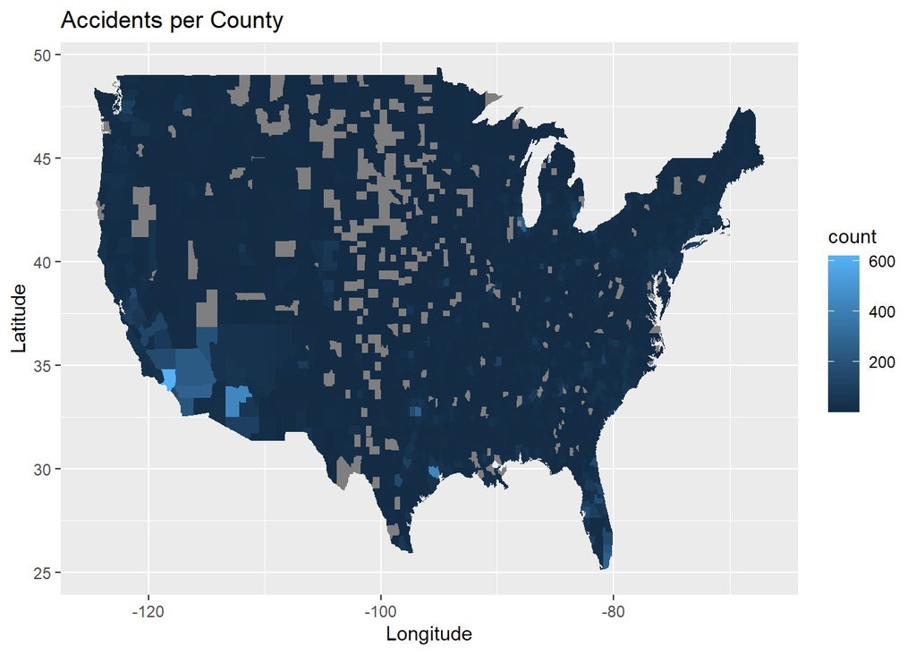

```r
glc <- glc %>%
  select('State Name', STATE = 'State Code', COUNTY = 'County Code', 'County Name') %>%
  mutate(STATE= as.integer(STATE),COUNTY= as.integer(COUNTY)) %>%
  mutate(`County Name`=tolower(`County Name`),`State Name`=tolower(`State Name`)) %>%
  unique()
acc2<-acc %>%
  group_by(STATE,COUNTY)%>%
  summarize(count=n())%>%
  select(STATE,COUNTY,count)%>%
  left_join(glc,by=c('STATE','COUNTY'))

counties <- map_data('county')
counties <- counties %>%
   mutate(`State Name` = region, `County Name` = subregion) %>%
   select(`State Name`, `County Name`, long, lat, group, order)

acc2<-acc2 %>%
  full_join(counties,by=c('State Name','County Name'))


ggplot(acc2,aes(x=long,y=lat,fill=count))+geom_polygon(aes(group=group))+labs(x="Longitude",y="Latitude",title = "Accidents per County")
```

Here we see that a lot of counties have less than 250 accidents with ones that are higher than average being more frequent in the southern united states.

**9. Can you find seasonal trends in accident occurrences in different states? Is summer or winter more dangerous? Why?**

[figure not shown]

```r
monthlyacc = acc %>%
  select(STATE, MONTH) %>%
  left_join(glc, by=c('STATE')) %>%
  rename('state_name' = 'State Name') %>% filter(state_name %in% c('iowa', 'texas', 'florida','oregon'))
monthlyacc %>% group_by(state_name, MONTH) %>% ggplot(aes(x=MONTH)) + geom_bar() + facet_wrap(~state_name) + labs(x="Month",y="Number of Accidents",title="Accidents in Florida,Iowa,Texas and Oregon")
```

Here we see that fatal accidents seem to have an even spread no matter what month it is, in Iowa however we do see a slight spike in accidents happening from june-september and again in december. This could be because of the frequent travel during those months and as we see that is not the same trend as oregon, florida and texas.